# SHAP en R

```r
require("data.table")
require("reticulate")
set.seed(123)
```

# Exploración de SHAP

Algunas explicaciones sobre el método provienen directamente de la documentación de la biblioteca citada en el [repo oficial](https://github.com/slundberg/shap)

## Carga de datasets

```r
dataset_c1 <- fread("C:/Users/PC/Documents/DMEyF/datasets/competencia1_2022.csv", stringsAsFactors= TRUE)
Xtrain <- dataset_c1[foto_mes == 202101,]
ytrain  <-  Xtrain[, clase_ternaria :=  ifelse( clase_ternaria =="CONTINUA", "0", "1" )  ]
```

```r
Xbajas = dataset_c1[foto_mes == 202101 & clase_ternaria != 'CONTINUA',]
Xcontinuan = dataset_c1[foto_mes == 202101 & clase_ternaria == 'CONTINUA',]
Xbajas <- Xbajas[, !"clase_ternaria", with = FALSE]
Xcontinuan <- Xcontinuan[, !"clase_ternaria", with = FALSE]

rm(dataset_c1)
gc()
```

```
##            used  (Mb) gc trigger  (Mb) max used  (Mb)
## Ncells  1749571  93.5    2785725 148.8  2785725 148.8
## Vcells 39834688 304.0  107582489 820.8 95042865 725.2
```

```r
Xtrain <- Xtrain[, !"clase_ternaria", with = FALSE]
```

## Modelito en LGBM

```python
import lightgbm as lgb
import pandas as pd

# dtrain  <- lgb.Dataset( data= data.matrix(Xtrain),
#                           label= ytrain,
#                           free_raw_data= FALSE
#                         )
#
#
# modelo  <- lgb.train( data= dtrain,
#                       param= list( objective=          "binary",
#                                    max_bin=           15,
#                                    learning_rate=     0.05,
#                                    min_data_in_leaf=   4000,
#                                    verbose = 2,
#                                    num_iterations= 100
#                                   )
#                     )
# create dataset for lightgbm
lgb_train = lgb.Dataset(r.Xtrain, r.ytrain['clase_ternaria'].values)

# specify your configurations as a dict
params = {
    'objective': 'binary',
    'learning_rate': 0.05,
    'verbose': 2,
    'max_bin': 15,
    'min_data_in_leaf': 4000,
    'verbose': 0,
}

gbm = lgb.train(params,
                lgb_train,
                num_boost_round=100)
```

[output not shown]

### Feature importance enlatado de LGBM

```python
lgbm_importancia = pd.DataFrame({'Features': gbm.feature_name(),
                        'Importances': gbm.feature_importance()})
lgbm_importancia.sort_values(by='Importances', inplace=True, ascending=False)
lgbm_importancia
```

```
##                        Features  Importances
## 5                  cliente_edad          141
## 107                ctrx_quarter          127
## 8          mrentabilidad_annual          120
## 10              mactivos_margen           98
## 97   chomebanking_transacciones           90
## ..                          ...          ...
## 76                   cforex_buy            0
## 75                       cforex            0
## 70   mtarjeta_master_descuentos            0
## 69   ctarjeta_master_descuentos            0
## 77                   mforex_buy            0
##
## [154 rows x 2 columns]
```

### SHAP

Queremos comprender cómo el modelo trató a las bajas de ese mes, por lo que aplicamos SHAP solo a las bajas:

```python
import shap
explainer = shap.TreeExplainer(gbm)
shap_values_Xbajas = explainer.shap_values(r.Xbajas)
```

```
## LightGBM binary classifier with TreeExplainer shap values output has changed to a list of ndarray
```

El TreeExplainer de las bajas es un array, con tantos elementos como clases existan. Se ve claramente que cada elemento del array contiene los mismos valores, pero con distinto signo.

```python
shap_values_Xbajas[0]
```

```
## array([[-0.00417813,  0.        ,  0.        , ..., -0.00320971,
##          0.        , -0.05980449],
##        [-0.00865486,  0.        ,  0.        , ...,  0.00388808,
##          0.        , -0.09774366],
##        [-0.00925333,  0.        ,  0.        , ..., -0.00425815,
##          0.        ,  0.02711597],
##        ...,
##        [-0.00247861,  0.        ,  0.        , ...,  0.00077788,
##          0.        , -0.14005166],
##        [ 0.00634482,  0.        ,  0.        , ..., -0.00081235,
##          0.        , -0.06344191],
##        [ 0.02293317,  0.        ,  0.        , ...,  0.0019713 ,
##          0.        , -0.09543813]])
```

```python
shap_values_Xbajas[1]
```

```
## array([[ 0.00417813,  0.        ,  0.        , ...,  0.00320971,
##          0.        ,  0.05980449],
##        [ 0.00865486,  0.        ,  0.        , ..., -0.00388808,
##          0.        ,  0.09774366],
##        [ 0.00925333,  0.        ,  0.        , ...,  0.00425815,
##          0.        , -0.02711597],
##        ...,
##        [ 0.00247861,  0.        ,  0.        , ..., -0.00077788,
##          0.        ,  0.14005166],
##        [-0.00634482,  0.        ,  0.        , ...,  0.00081235,
##          0.        ,  0.06344191],
##        [-0.02293317,  0.        ,  0.        , ..., -0.0019713 ,
##          0.        ,  0.09543813]])
```

```python
import pandas as pd
shap_bajas = pd.DataFrame(shap_values_Xbajas[0], columns = r.Xbajas.columns)
shap_bajas
```

```
##       numero_de_cliente  foto_mes  ...  Visa_cadelantosefectivo  Visa_mpagominimo
## 0             -0.004178       0.0  ...                      0.0         -0.059804
## 1             -0.008655       0.0  ...                      0.0         -0.097744
## 2             -0.009253       0.0  ...                      0.0          0.027116
## 3             -0.001536       0.0  ...                      0.0         -0.109547
## 4              0.004478       0.0  ...                      0.0         -0.119615
## ...                 ...       ...  ...                      ...               ...
## 1509           0.007896       0.0  ...                      0.0          0.087809
## 1510           0.003991       0.0  ...                      0.0         -0.084133
## 1511          -0.002479       0.0  ...                      0.0         -0.140052
## 1512           0.006345       0.0  ...                      0.0         -0.063442
## 1513           0.022933       0.0  ...                      0.0         -0.095438
##
## [1514 rows x 154 columns]
```

```python
shap_importancias_bajas = shap_bajas.mean().abs().sort_values(ascending=False)
shap_importancias_bajas
```

```
## ctrx_quarter                   0.962102
## cpayroll_trx                   0.608363
## mtarjeta_visa_consumo          0.164559
## mcuentas_saldo                 0.164378
## mpasivos_margen                0.148706
##                                  ...
## mpagodeservicios               0.000000
## Master_delinquency             0.000000
## tmobile_app                    0.000000
## ccajeros_propios_descuentos    0.000000
## cforex_buy                     0.000000
## Length: 154, dtype: float64
```

Ploteamos los shap values del modelo aplicado a Xbajas. El largo de la barra nos dice que tanta influencia la variable tiene en la predicción. Se ve como cada variable esta dividida equitativamente en dos clases, lo cual tiene sentido dado que la contribución a cada clase es la misma (pero negativa o positiva)

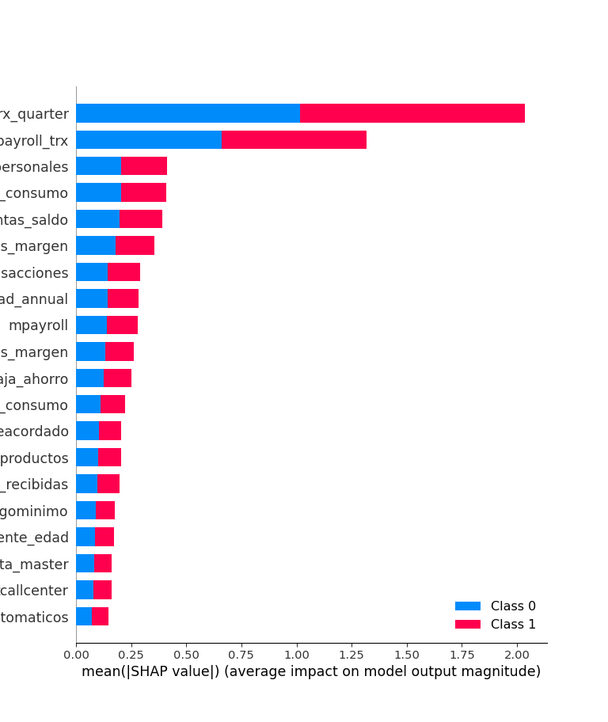

```python
shap.summary_plot(shap_values_Xbajas, r.Xbajas)
```

Vemos el dependence plot, un scatter plot que muestra el efecto de una variable en las predicciones del modelo. El color corresponde a una segunda variable que puede tener un efecto de interacción con la variable que estamos ploteando inicialmente. Esta segunda variable de elige de manera automática.

```
## invalid value encountered in reduce
## invalid value encountered in reduce
## invalid value encountered in subtract
```

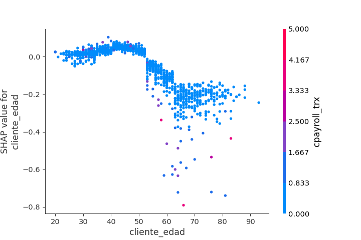

```python
shap.dependence_plot("cliente_edad", shap_values_Xbajas[0], r.Xbajas)
```

Probamos el mismo proceso con el dataset de clientes que continuan

```python
shap_values_Xcontinuan = explainer.shap_values(r.Xcontinuan)
```

```
## LightGBM binary classifier with TreeExplainer shap values output has changed to a list of ndarray
```

```python
shap_continuan = pd.DataFrame(shap_values_Xcontinuan[0], columns = r.Xcontinuan.columns)
shap_continuan
```

```
##         numero_de_cliente  foto_mes  ...  Visa_cadelantosefectivo  Visa_mpagominimo
## 0               -0.053972       0.0  ...                      0.0          0.012533
## 1               -0.005096       0.0  ...                      0.0         -0.051719
## 2               -0.004589       0.0  ...                      0.0          0.131031
## 3               -0.029915       0.0  ...                      0.0          0.007456
## 4               -0.020423       0.0  ...                      0.0          0.129476
## ...                   ...       ...  ...                      ...               ...
## 159823           0.002187       0.0  ...                      0.0         -0.117932
## 159824           0.021524       0.0  ...                      0.0         -0.107181
## 159825           0.023863       0.0  ...                      0.0         -0.084864
## 159826           0.012419       0.0  ...                      0.0         -0.084705
## 159827          -0.000485       0.0  ...                      0.0         -0.078598
##
## [159828 rows x 154 columns]
```

```python
shap_importancias_continuan = shap_continuan.mean().abs().sort_values(ascending=False)
shap_importancias_continuan
```

```
## cpayroll_trx                   0.025513
## mcuentas_saldo                 0.020790
## ccomisiones_mantenimiento      0.019857
## cliente_edad                   0.019362
## mcaja_ahorro                   0.017490
##                                  ...
## Master_Finiciomora             0.000000
## ccajeros_propios_descuentos    0.000000
## mcajeros_propios_descuentos    0.000000
## ctarjeta_visa_descuentos       0.000000
## cforex_buy                     0.000000
## Length: 154, dtype: float64
```

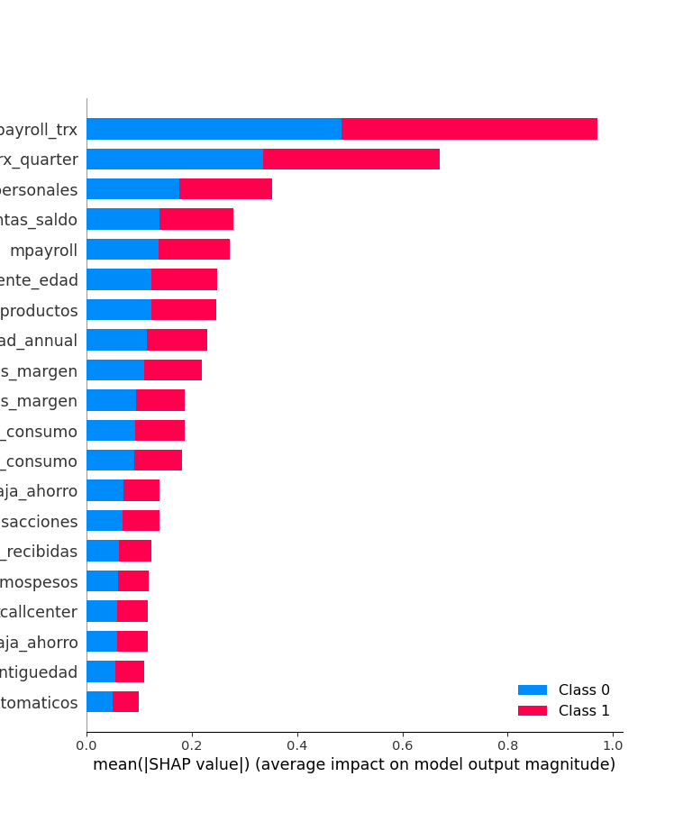

```python
shap.summary_plot(shap_values_Xcontinuan, r.Xcontinuan)
```

```
## invalid value encountered in reduce
## invalid value encountered in reduce
## invalid value encountered in subtract
```

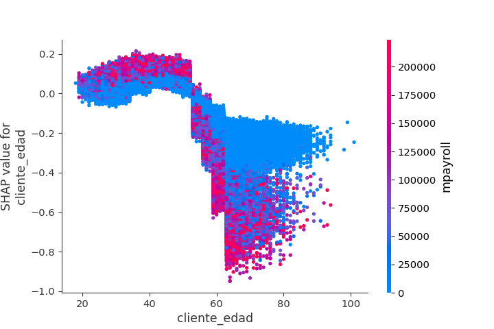

```python
shap.dependence_plot("cliente_edad", shap_values_Xcontinuan[0], r.Xcontinuan)
```

## Usando los valores en R

```r
py$shap_values_Xbajas
```

[output not shown]

[output cut: 32490 more lines]